# R Notebook

# Libraries

```r
library(tidyverse)
library(infer)
library(janitor)
```

```r
books <- read_csv("data/books.csv")
books_tidy <- books %>%
  clean_names() %>%
  filter(!is.na(average_rating)) %>%
  rename(num_pages = number_num_pages) %>%
  glimpse()
```

```
Rows: 10,999
Columns: 10
$ book_id            <dbl> 1, 2, 3, 4, 5, 8, 9, 10, 12, 13, 14, 16, 18, 21, 22, 23, 24, 25, 26, 27, 28, 29~
$ title              <chr> "Harry Potter and the Half-Blood Prince (Harry Potter  #6)", "Harry Potter and ~
$ authors            <chr> "J.K. Rowling-Mary GrandPré", "J.K. Rowling-Mary GrandPré", "J.K. Rowling-Mary ~
$ average_rating     <dbl> 4.56, 4.49, 4.47, 4.41, 4.55, 4.78, 3.69, 4.73, 4.38, 4.38, 4.22, 4.22, 4.38, 4~
$ isbn               <chr> "0439785960", "0439358078", "0439554934", "0439554896", "043965548X", "04396825~
$ isbn13             <chr> "9780439785969", "9780439358071", "9780439554930", "9780439554893", "9780439655~
$ language_code      <chr> "eng", "eng", "eng", "eng", "eng", "eng", "en-US", "eng", "eng", "eng", "eng", ~
$ num_pages          <dbl> 652, 870, 320, 352, 435, 2690, 152, 3342, 815, 815, 215, 6, 815, 544, 55, 256, ~
$ ratings_count      <dbl> 1944099, 1996446, 5629932, 6267, 2149872, 38872, 18, 27410, 3602, 240189, 4416,~
$ text_reviews_count <dbl> 26249, 27613, 70390, 272, 33964, 154, 1, 820, 258, 3954, 408, 253, 192, 8840, 4~
```

```r
books_tidy %>%
  ggplot(aes(x = average_rating)) +
  geom_histogram(col = "white")

books_tidy %>%
  ggplot(aes(x = average_rating)) +
  geom_jitter(aes(y = 0, height = .2)) +
  geom_boxplot(colour = 2)
```

[output not shown]

The data we have is from 2020 GoodReads database - we are going to test to see if the 2020 average is different from the 2016 average

```r
mean(books$average_rating, na.rm = TRUE)
```

```
[1] 3.937568
```

Set up two competing hypotheses Null hypothesis (H0) Is framed as the skeptical position … is the hypothesis of -no difference -no change -things are the same

Alternative hypothesis (H1) the hypothesis of difference

Null hypothesis The average rating from 2020 is not different from the average rating from 2016

Alternative hypothesis The average rating from 2020 is different from the average rating from 2016

Our 2 hypotheses must be -mutually exclusive -exhaustive

$$H_1 : \mu_{average\ rating} \neq 3.93$$

$$\mu = popluation\ mean \\\\\\\
\pi= population \ proportion \\\\\\\
\sigma = population \ standard deviation$$

```r
observed_stat(books$average_rating, na.rm = TRUE)
```

[output not shown]

Is this *significantly* different from 2016s 3.93

Steps of hypothesis test

1. Before we look at the data
   - decide on the significance level (alpha level): set the threshold for what counts as significant
   - set the error rate - it will dictate how often we wrongly declare significance
   - by convention, at least very often, the most common alpha level is 0.05
   - so with alpha 0.05, we can expect to wrongly reject the null hypothesis 1 time in 20
2. Calculate the statistic from the sample
   - in this case, it’s the mean
3. Create the sampling distribution - we’ll do this by bootstrapping
   - *very_important* - when we create the sampling distribution, we assume that it is TRUE
4. Compare the calculated statistic with the sampling distribution
   - If the calculated stat is far enough into the tail or our null distribution … we call it significant
   - *p-value*
5. Decide whether to reject the null hypothesis
   - If the p value is less than our alpha, we reject the null hypothesis. -We find evidence in support of H1
   - If the p value is more than our alpha, we fail to reject the null hypothesis -We didn’t find evidence in support of H1

```r
null_distribution <- books_tidy %>%
  specify(response = average_rating) %>%
  hypothesise(null = "point", mu = 3.93) %>%
  generate(reps = 1000, type = "bootstrap") %>%
  calculate(stat = "mean")
```

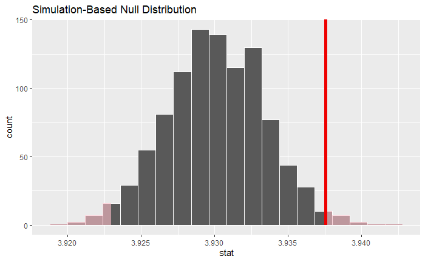

```r
null_distribution %>%
  visualise(bins =20) +
  shade_p_value(obs_stat = observed_stat, direction = "both")
```

| p_value |
| --- |
| 0.026 |

What does the p value mean? > How likely is it to see a result as extreme as your observed result, if the null hypothesis is true? > If the null was true, how weird would this data be?

*Don’t say* The p value is the probability that H0 is correct - it doesn’t mean that!

Our observed stat of 3.9376 is significantly different from our null stat of 3.93, at an alpha level of 0.05, we therefore find evidence in support of our alternative hypothesis

## Session 2 – One sample hypothesis tests - proportions

### Learning objectives

- Perform a one sample hypothesis test for proportion using computational methods
- Interpret results of a one-sample hypothesis test for proportion using computational methods

> Question

“Does the proportion of books in the Goodreads database that lack text reviews differ significantly from 7%?”

```r
books_tidy %>%
  group_by(text_reviews_count) %>%
  summarise(prop = n()/nrow(books_tidy)) %>%
  filter(text_reviews_count == 0)
```

| text_reviews_count | prop |
| --- | --- |
| 0 | 0.06455132 |

Null hypothesis The proportion of books that lack text reviews is not different from 7%

Alternative hypothesis The proportion of books that lack text reviews is different from 7%

Our 2 hypotheses must be -mutually exclusive -exhaustive

$$H_0 : \pi_{no \ reviews} = 7%$$

$$H_1 : \pi_{no\ reviews} \neq 7%$$

Steps of hypothesis test

1. Before we look at the data
   - decide on the significance level (alpha level): set the threshold for what counts as significant
   - set the error rate - it will dictate how often we wrongly declare significance
   - by convention, at least very often, the most common alpha level is 0.05
   - so with alpha 0.05, we can expect to wrongly reject the null hypothesis 1 time in 20
2. Calculate the statistic from the sample
   - in this case, it’s the proportion
     $$\frac{number\ of\ books\ with\ no\ text\ review}{total\ number\ of\
     books}$$
3. Create the sampling distribution - we’ll do this by bootstrapping
   - *very_important* - when we create the sampling distribution, we assume that it is TRUE
4. Compare the calculated statistic with the sampling distribution
   - If the calculated stat is far enough into the tail or our null distribution … we call it significant
   - *p-value*
5. Decide whether to reject the null hypothesis
   - If the p value is less than our alpha, we reject the null hypothesis. -We find evidence in support of H1
   - If the p value is more than our alpha, we fail to reject the null hypothesis -We didn’t find evidence in support of H1

```r
mean(books_tidy_prop$has_review)
```

```
[1] 0.9354487
```

```r
null_distribution
```

```
Response: has_review (factor)
Null Hypothesis: point
```

| replicate | stat |
| --- | --- |
| 1 | 0.06800618 |
| 2 | 0.06864260 |
| 3 | 0.07609783 |
| 4 | 0.06691517 |
| 5 | 0.06755160 |
| 6 | 0.07409765 |
| 7 | 0.06809710 |
| 8 | 0.06891536 |
| 9 | 0.07427948 |
| 10 | 0.06855169 |

[output cut: 990 more lines]

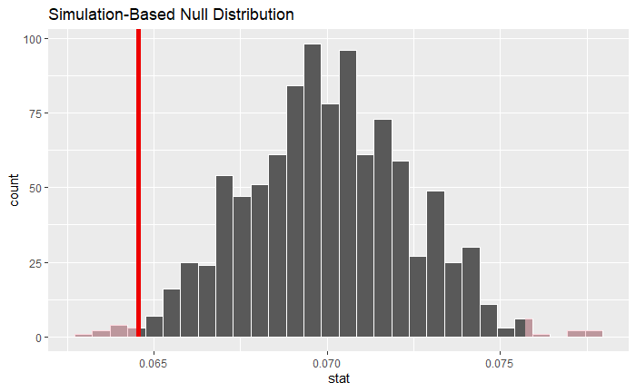

| p_value |
| --- |
| 0.018 |

Since the p value is less than alpha, we can reject the null hypothesis

The most common alpha is 0.05 Psych - usually uses 0.1 Other fields use 0.01

## Session 3 - Two sample hypothesis tests

### Learning Objectives

- Know the difference between independent and paired two-sample tests. -Be able to use computational methods to perform and interpret -a paired two sample hypothesis test -an independent two-sample hypothesis test -a proportion two-sample hypothesis test

### Data

```r
nice <- read_csv("data/nice.csv")
algarve <- read_csv("data/algarve.csv")
corfu <- read_csv("data/corfu.csv")
florence <- read_csv("data/florence.csv")
```

### Independent samples

Remember independent means the observations are not associated with each other

H0 - There is no difference in the mean prices for a 2 - bedroom, 14 day holiday apartment let in Nice and the Algarve

H1 - The mean price for a 2-bedroom, 14 day holiday apartment let in the Algarve is higher than the mean price for a 2-bedroom, 14 day holiday apartment let in Nice

```r
apart_prices <- bind_rows(nice = nice,
                          algarve = algarve,
                          .id = "location")

apart_prices
```

| location | ...1 | price |
| --- | --- | --- |
| nice | 1 | 1594 |
| nice | 2 | 1537 |
| nice | 3 | 1565 |
| nice | 4 | 1477 |
| nice | 5 | 2072 |
| nice | 6 | 1608 |
| nice | 7 | 1482 |
| nice | 8 | 2249 |
| nice | 9 | 2238 |
| nice | 10 | 1761 |

[output cut: 90 more lines]

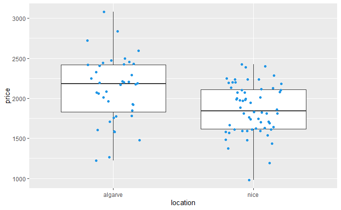

```r
null_distribution <- apart_prices %>%
  #specify(response = price, explanatory = location)
  specify(price ~ location) %>%
  hypothesise(null = "independence") %>%
  generate(reps = 5000, type = "permute") %>%
  calculate(stat = "diff in means", order = c("algarve", "nice"))
```

```r
observed_stat
```

[output not shown]

[output not shown]

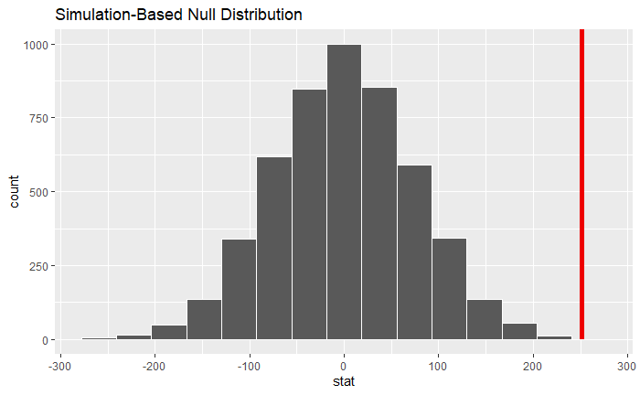

```r
null_distribution %>%
  visualise() +
  shade_p_value(obs_stat = observed_stat, direction = "right")
```

| p_value |
| --- |
| 0.0002 |

H0 Price Florence = Corfu H1 Price Florence < Corfu

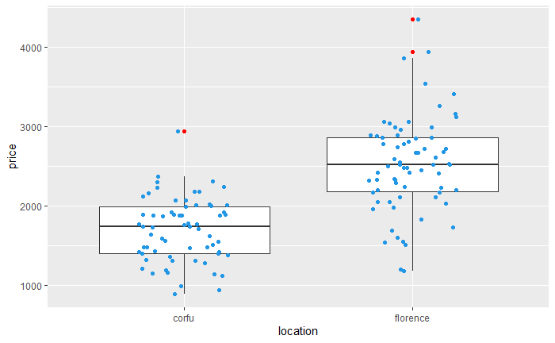

```r
apart_prices_cor_flo %>%
  ggplot(aes(x = location,
             y = price)) +
  geom_boxplot(outlier.color = "red") +
  geom_jitter(width = .2, colour = 4)
```

```r
null_distribution <- apart_prices_cor_flo %>%
  #specify(response = price, explanatory = location)
  specify(price ~ location) %>%
  hypothesise(null = "independence") %>%
  generate(reps = 5000, type = "permute") %>%
  calculate(stat = "diff in means", order = c("florence", "corfu"))
```

```r
observed_stat <- apart_prices_cor_flo %>%
  specify(price ~ location) %>%
  calculate(stat = "diff in means", order = c("florence", "corfu"))
```

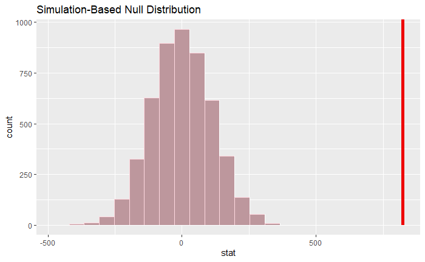

```r
null_distribution %>%
  visualise() +
  shade_p_value(obs_stat = observed_stat, direction = "left")
```

```r
p_value <- null_distribution %>%
  get_p_value(obs_stat = observed_stat, direction = "left")

options(scipen = 999)

p_value
```

| p_value |
| --- |
| 1 |

price for new texts in campus bookstore = price for new texts on Amazon price for new texts in campus bookstore != price for new texts on Amazon

0.05 or 95% CI

```r
textbooks <- read_csv("data/ucla_textbooks_f18.csv")
```

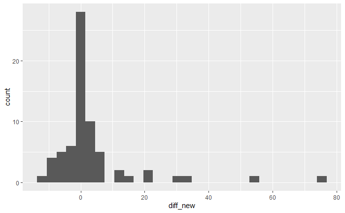

```r
books_diff <- textbooks %>%
  mutate(diff_new = bookstore_new - amazon_new) %>%
  filter(!is.na(diff_new))

books_diff %>%
  ggplot(aes(x = diff_new)) +
  geom_histogram()
```

naked stats Ucal 10 Amazon 12

[output not shown]

Task 10 min

Frame and perform a paired hypothesis test to answer the following question:

On average are the prices of the used course texts lower on amazon than at the campus bookstore

H0 - price for used texts in campus bookstore = price for used texts on Amazon H1 - price for used texts on Amazon < price for used texts on campus

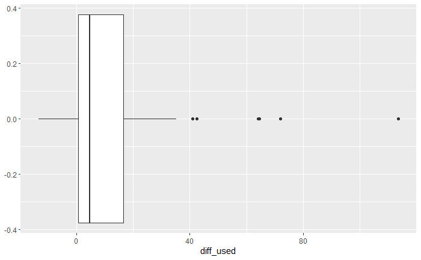

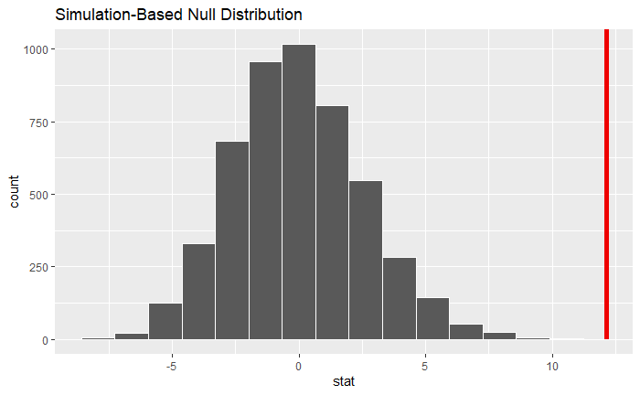

```r
null_distribution <- books_diff_used %>%
  specify(response = diff_used) %>%
  hypothesise(null = "point", mu = 0) %>%
  generate(reps = 5000, type = "bootstrap") %>%
  calculate(stat = "mean")

observed_stat <- books_diff_used %>%
  specify(response = diff_used) %>%
  calculate(stat = "mean")

null_distribution %>%
  visualise() +
  shade_p_value(observed_stat, direction = "right")
```

```r
null_distribution %>%
  get_p_value(observed_stat, direction = "right")
```

| p_value |
| --- |
| 0 |

## Infer procedure

1. Calculate the *observed* statistic
   1. Create *“flag”* column if necessary
   2. Specify the *response* variable
   3. Calculate the required *stat* e.g. prop / mean
2. Generate the *null distribution*
   1. Specify the *response*
   2. Indicate the *hypothesis* What type of hypothesis (e.g. point) Specify the proportion p (the observed stat)
   3. Generate the *null distribution*
   4. Calculate the *stat* of interest
3. *Visualize* the resut Shade p-value region
4. Extract the *p-value*

```r
s <- rnorm(100, 101, sd = 2)

#Is the mean of the sample different from the mean of the pop
t.test(s, mu = p_mean)
```

```
    One Sample t-test

data:  s
t = 4.5476, df = 99, p-value = 0.0000154
alternative hypothesis: true mean is not equal to 100
95 percent confidence interval:
 100.4838 101.2327
sample estimates:
mean of x
 100.8583
```